# Eval_Lab

Nathan Lindley

10/13/2022

The most important part of any machine learning model(or any model, really) is understanding and defining the models weaknesses and/or vulnerabilities.

To do so we are going to practice on a familiar dataset and use a method we just learned, kNN. For this lab use the Job Placement or Bank dataset.

```r
library(tidyverse)
library(dplyr)
library(caret)
library(RColorBrewer)
library(ROCR)
#install.packages("MLmetrics")
library(MLmetrics)
library(mltools)
library(data.table)
```

Part 1. Develop a ML question using status as the target variable. In consideration of all the metrics we discussed what are a couple of key metrics that should be tracked given the question you are trying to solve?

How well we can predict whether someone gets placed or not. Metrics to be tracked would be the log loss, and the accuracy.

Part 2. Create a kNN model that can answer your question, using all the appropriate prep methods we discussed.

```r
df <- read_csv("~/DS-3001/myWork/Placement_Data_Full_Class.csv")
# Data Prep
df <- select(df, -salary)
df <- df[complete.cases(df),]
table(df$specialisation)
```

```
##
## Mkt&Fin  Mkt&HR
##     120      95
```

```r
df$workex <- recode(df$workex, 'Yes' = 1, 'No' = 0)
df$status <- recode(df$status, 'Placed' = 1, 'Not Placed' = 0)
factor_columns <- c(2,4,6,7,9,10,12)
df[,factor_columns] <- lapply(df[,factor_columns], as_factor)
str(df)
```

```
## tibble [215 × 14] (S3: tbl_df/tbl/data.frame)
##  $ sl_no         : num [1:215] 1 2 3 4 5 6 7 8 9 10 ...
##  $ gender        : Factor w/ 2 levels "M","F": 1 1 1 1 1 1 2 1 1 1 ...
##  $ ssc_p         : num [1:215] 67 79.3 65 56 85.8 ...
##  $ ssc_b         : Factor w/ 2 levels "Others","Central": 1 2 2 2 2 1 1 2 2 2 ...
##  $ hsc_p         : num [1:215] 91 78.3 68 52 73.6 ...
##  $ hsc_b         : Factor w/ 2 levels "Others","Central": 1 1 2 2 2 1 1 2 2 2 ...
##  $ hsc_s         : Factor w/ 3 levels "Commerce","Science",..: 1 2 3 2 1 2 1 2 1 1 ...
##  $ degree_p      : num [1:215] 58 77.5 64 52 73.3 ...
##  $ degree_t      : Factor w/ 3 levels "Sci&Tech","Comm&Mgmt",..: 1 1 2 1 2 1 2 1 2 2 ...
##  $ workex        : Factor w/ 2 levels "0","1": 1 2 1 1 1 2 1 2 1 1 ...
##  $ etest_p       : num [1:215] 55 86.5 75 66 96.8 ...
##  $ specialisation: Factor w/ 2 levels "Mkt&HR","Mkt&Fin": 1 2 2 1 2 2 2 2 2 2 ...
##  $ mba_p         : num [1:215] 58.8 66.3 57.8 59.4 55.5 ...
##  $ status        : num [1:215] 1 1 1 0 1 0 0 1 1 0 ...
```

```r
factor_column_names <- names(select_if(df, is.factor))
df <- one_hot(as.data.table(df), cols=factor_column_names)
df$status = as.factor(df$status)
```

```r
# Decision Tree
colnames(df) <- make.names(colnames(df))
split_index <- createDataPartition(df$status, p = .8, #selects the split, 80% training 20% for test
                                  list = FALSE,#output of the data, we don't want a list
                                  times = 1)#the number of partitions to create we just want one

traindf <- df[split_index,]
dim(traindf)
```

```
## [1] 173  23
```

```r
test <- df[-split_index,]
dim(test)
```

```
## [1] 42 23
```

```r
set.seed(2002)
status_tree <- train(status~., data=traindf, method='rpart')

status_tree
```

```
## CART
##
## 173 samples
##  22 predictor
##   2 classes: '0', '1'
##
## No pre-processing
## Resampling: Bootstrapped (25 reps)
## Summary of sample sizes: 173, 173, 173, 173, 173, 173, ...
## Resampling results across tuning parameters:
##
##   cp          Accuracy   Kappa
##   0.03703704  0.7949647  0.5067013
##   0.10185185  0.7796814  0.4745912
##   0.37037037  0.7617133  0.4059675
##
## Accuracy was used to select the optimal model using the largest value.
## The final value used for the model was cp = 0.03703704.
```

```r
resamples <- tibble(status_tree$resample)

mean(resamples$Accuracy)
```

```
## [1] 0.7949647
```

```r
status_tree$finalModel$variable.importance
```

```
##           ssc_p           hsc_p        degree_p           mba_p           sl_no
##      28.6813441      17.9319823      15.8939053       8.0107134       2.7882509
##         etest_p degree_t_Others   hsc_s_Science        gender_F        gender_M
##       1.8287585       0.3912037       0.3912037       0.3449232       0.3449232
```

Part 3. Evaluate the model using the metrics you identified in the first question. Make sure to calculate/reference the prevalence to provide a baseline for some of these measures. Summarize the output of the key metrics you established in part 1.

```r
# Prediction and evaluation
status_eval <- predict(status_tree, newdata=test)
status_eval
```

```
##  [1] 1 1 0 1 1 0 1 1 0 1 1 0 0 1 1 0 1 1 1 1 1 1 1 1 1 1 1 1 0 1 1 1 1 1 0 1 1 1
## [39] 1 0 1 1
## Levels: 0 1
```

```r
status_eval_prob <- predict(status_tree, newdata=test, type='prob')
status_eval_prob
```

```
##             0         1
## 1  0.07920792 0.9207921
## 2  0.07920792 0.9207921
## 3  1.00000000 0.0000000
## 4  0.23809524 0.7619048
## 5  0.07920792 0.9207921
## 6  1.00000000 0.0000000
## 7  0.07920792 0.9207921
## 8  0.07920792 0.9207921
## 9  1.00000000 0.0000000
## 10 0.07920792 0.9207921
## 11 0.07920792 0.9207921
## 12 0.62962963 0.3703704
## 13 0.62962963 0.3703704
## 14 0.07920792 0.9207921
```

[output cut: 28 more lines]

```r
table(status_eval, test$status)
```

```
##
## status_eval  0  1
##           0  7  2
##           1  6 27
```

```r
confusionMatrix(status_eval, test$status, positive='1', dnn=c('Prediction','Actual'), mode='everything')
```

```
## Confusion Matrix and Statistics
##
##           Actual
## Prediction  0  1
##          0  7  2
##          1  6 27
##
##                Accuracy : 0.8095
##                  95% CI : (0.6588, 0.914)
##     No Information Rate : 0.6905
##     P-Value [Acc > NIR] : 0.06218
##
##                   Kappa : 0.513
##
##  Mcnemar's Test P-Value : 0.28884
##
##             Sensitivity : 0.9310
##             Specificity : 0.5385
##          Pos Pred Value : 0.8182
##          Neg Pred Value : 0.7778
##               Precision : 0.8182
##                  Recall : 0.9310
##                      F1 : 0.8710
##              Prevalence : 0.6905
##          Detection Rate : 0.6429
##    Detection Prevalence : 0.7857
##       Balanced Accuracy : 0.7347
##
##        'Positive' Class : 1
##
```

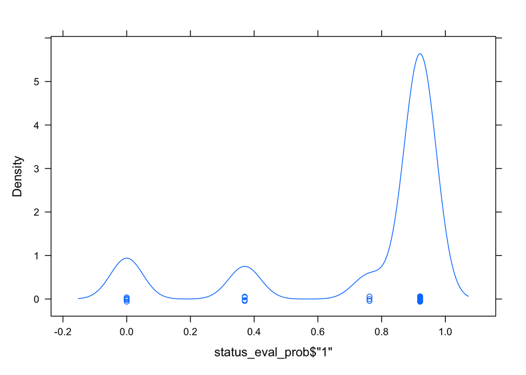

```r
densityplot(status_eval_prob$'1')
```

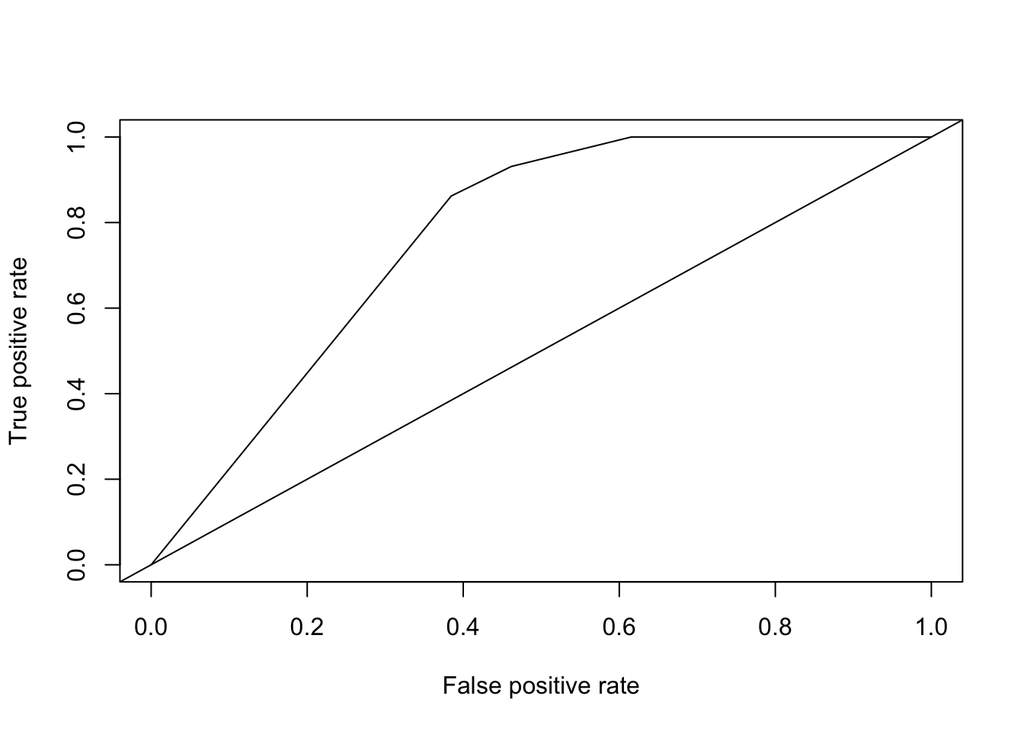

```r
full_pred <- tibble(pred_class=status_eval, pred_prob=status_eval_prob$'1', target=test$status)

index_poss <- apply(full_pred, 2, function(x) full_pred$pred_class==full_pred$target)

pred <- prediction(full_pred$pred_prob, full_pred$target)

tree_perf <- performance(pred, 'tpr', 'fpr')
plot(tree_perf)
abline(a=0,b=1)
```

```r
tree_perf_AUC <- performance(pred,"auc")
print(tree_perf_AUC@y.values)
```

```
## [[1]]
## [1] 0.7679045
```

```r
## LogLoss

LogLoss(full_pred$pred_prob, as.numeric(test$status))
```

```
## [1] 2.794389
```

```r
table(test$status)
```

```
##
##  0  1
## 13 29
```

```r
29/42
```

```
## [1] 0.6904762
```

```r
-log(29/42)
```

```
## [1] 0.3703738
```

```r
#pretty terrible model based on this metric
```

Part 4. Consider where miss-classification errors (via confusion matrix) are occurring, is there a pattern? If so discuss this pattern and why you think this is the case.

There doesn’t appear to be a pattern as to who is classified incorrectly, at least not a pattern I could discern from looking through the data.

Part 5. Based on your exploration in Part 4, change the threshold using the function provided in the in-class example, what differences do you see in the evaluation metrics? Speak specifically to the metrics that are best suited to address the question you are trying to answer from part 1.

```r
adjust_thres <- function(x, y, z) {
  #x=pred_probablities, y=threshold, z=test_outcome
  thres <- as.factor(ifelse(x > y, 1,0))
  confusionMatrix(thres, z, positive = "1", dnn=c("Prediction", "Actual"), mode = "everything")
}

adjust_thres(status_eval_prob$'1', .45, test$status)
```

```
## Confusion Matrix and Statistics
##
##           Actual
## Prediction  0  1
##          0  7  2
##          1  6 27
##
##                Accuracy : 0.8095
##                  95% CI : (0.6588, 0.914)
##     No Information Rate : 0.6905
##     P-Value [Acc > NIR] : 0.06218
##
##                   Kappa : 0.513
##
##  Mcnemar's Test P-Value : 0.28884
##
##             Sensitivity : 0.9310
##             Specificity : 0.5385
##          Pos Pred Value : 0.8182
##          Neg Pred Value : 0.7778
##               Precision : 0.8182
##                  Recall : 0.9310
##                      F1 : 0.8710
##              Prevalence : 0.6905
##          Detection Rate : 0.6429
##    Detection Prevalence : 0.7857
##       Balanced Accuracy : 0.7347
##
##        'Positive' Class : 1
##
```

Based on both the density plot and some experimentation with the `adjust_thres` function I was unable to find any thresdhold value that significantly increased my algorithm’s accuracy score.

Part 6. Summarize your findings (a paragraph or two) speaking through your question, what does the evaluation outputs mean when answering the question you’ve proposed?

Submit a .Rmd file along with the data used or access to the data sources to the Collab site. You can work together with your groups but submit individually and generate your own R file.